# Elezioni Emilia-Romagna

Author

Luca Fornasari

Published

June 24, 2024

Questo report contiene i risultati di una simulazione delle prossime elezioni del Consiglio della Regione Emilia-Romagna, ottenuti partendo dai risultati delle elezioni europee 2024. Vengono eseguite 1000 simulazioni, in ciascuna di esse le percentuali che ciascuna lista ha preso alle elezioni europee in ciascuna provincia vengono aumentate o diminuite casualmente di una quantità che sia coerente con la variabilità che ha avuto nel passato la percentuale di quella lista. Per i dettagli vedere in fondo negli approfondimenti.

Avverto che ho fatto questa simulazione per curiosità e non per lavoro, e che potrebbero essermi sfuggiti degli errori nel processo di simulazione, i risultati vanno dunque presi senza alcuna garanzia di accuratezza.

Segnalazioni, richieste e suggerimenti a fornaeffe@gmail.com o sul repository https://github.com/fornaeffe/elezioni-EMR.

## Dati

Liste

| COALIZIONE | LISTA |
| --- | --- |
| SINISTRA | ALLEANZA VERDI E SINISTRA |
| CENTRO | AZIONE |
| DESTRA | FORZA ITALIA |
| DESTRA | FRATELLI D'ITALIA |
| DESTRA | LEGA |
| M5S | MOVIMENTO 5 STELLE |
| SINISTRA | PARTITO DEMOCRATICO |
| CENTRO | STATI UNITI D'EUROPA |

## Risultati

### Percentuali per lista

Questo grafico mostra le percentuali simulate per ciascuna lista.

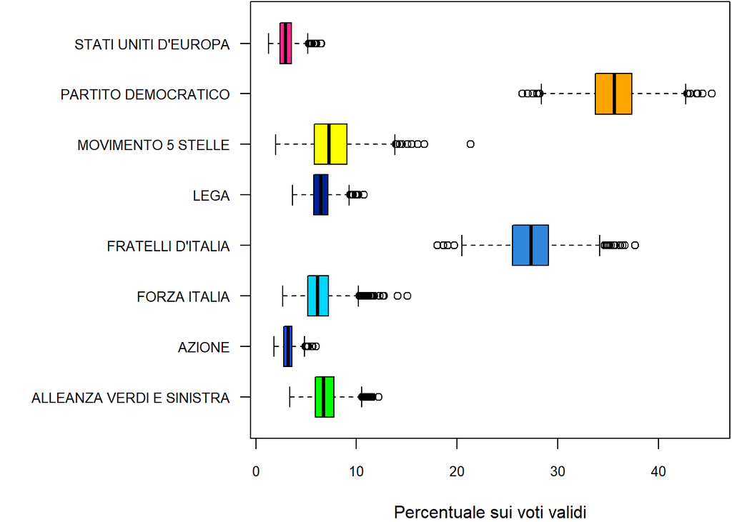

### Coalizioni vincenti

Probabilità di vittoria

| COALIZIONE | Prob. |
| --- | --- |
| DESTRA | 33% |
| SINISTRA | 67% |

### Composizione media del Consiglio Regionale

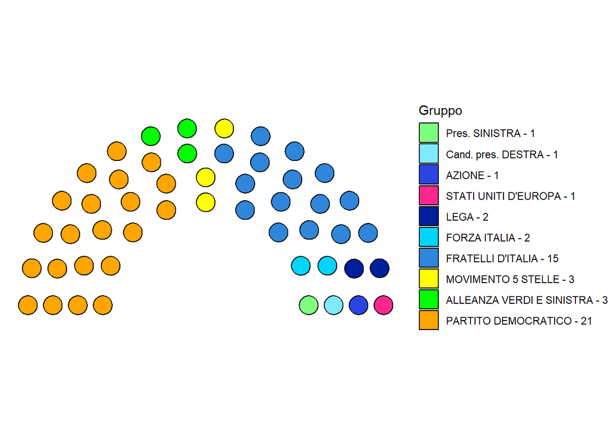

### Probabilità di eleggere qualcuno

Prob. di eleggere qualcuno

| LISTA | Prob. |
| --- | --- |
| ALLEANZA VERDI E SINISTRA | 99% |
| AZIONE | 91% |
| FORZA ITALIA | 99% |
| FRATELLI D'ITALIA | 100% |
| LEGA | 100% |
| MOVIMENTO 5 STELLE | 100% |
| PARTITO DEMOCRATICO | 100% |
| STATI UNITI D'EUROPA | 90% |

### Numero di seggi rispetto alle percentuali ottenute

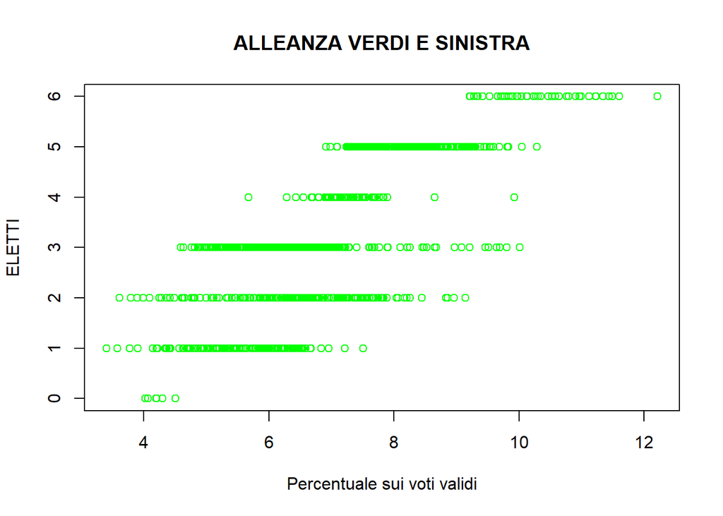

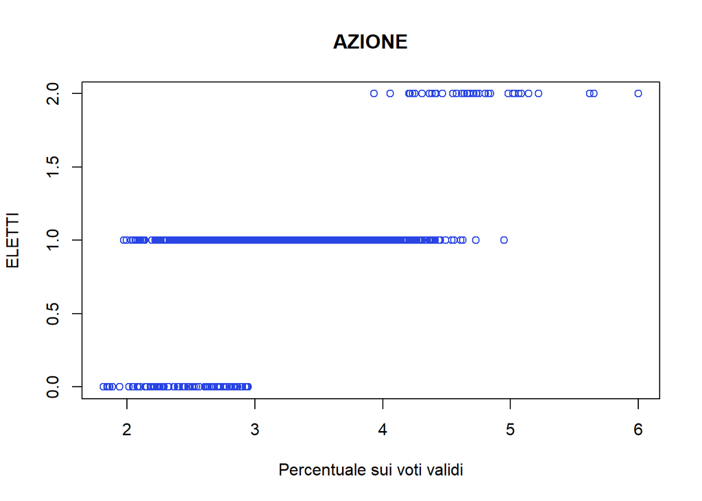

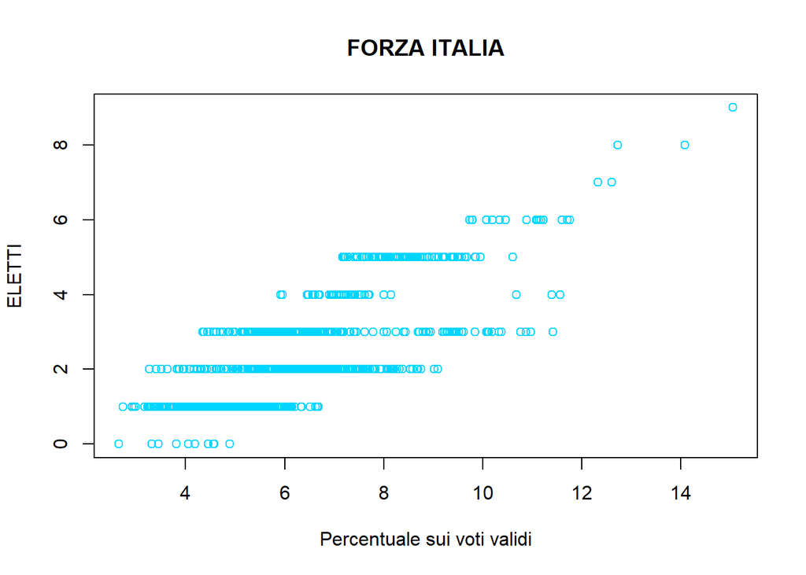

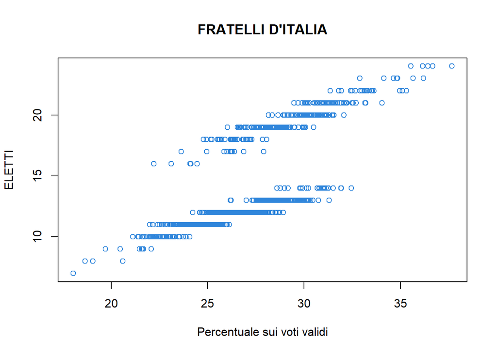

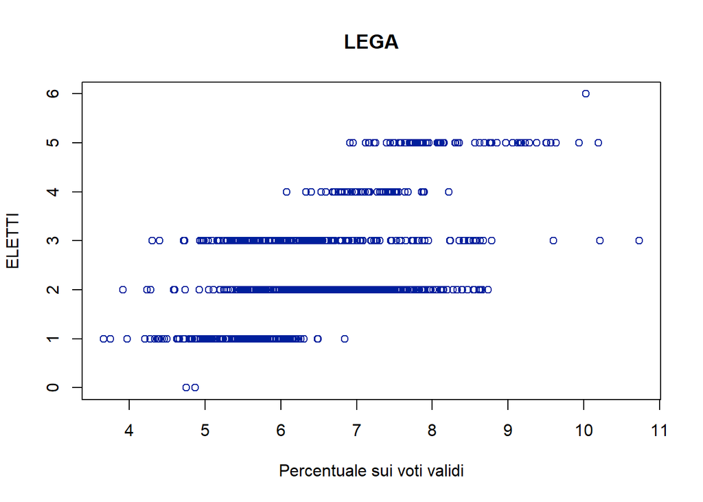

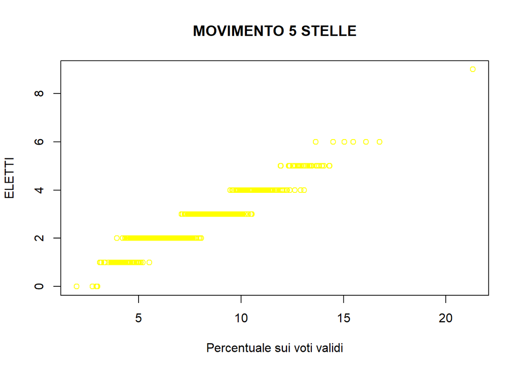

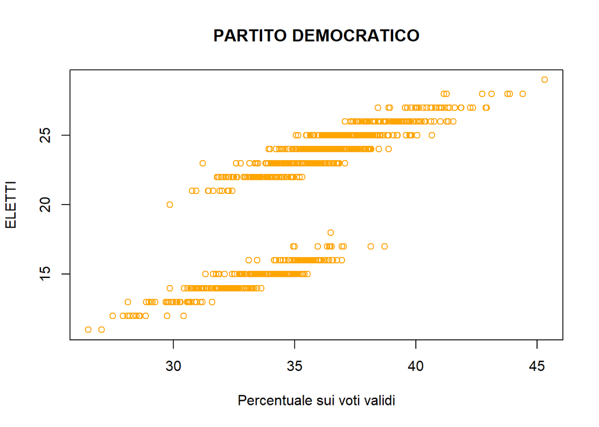

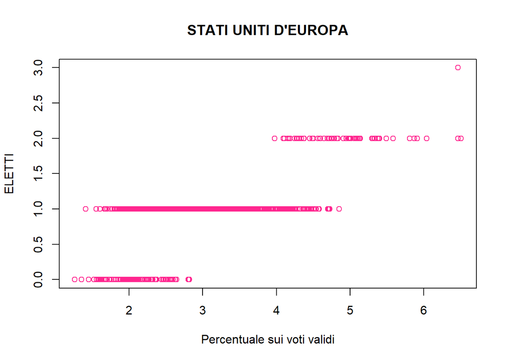

#### Per coalizione

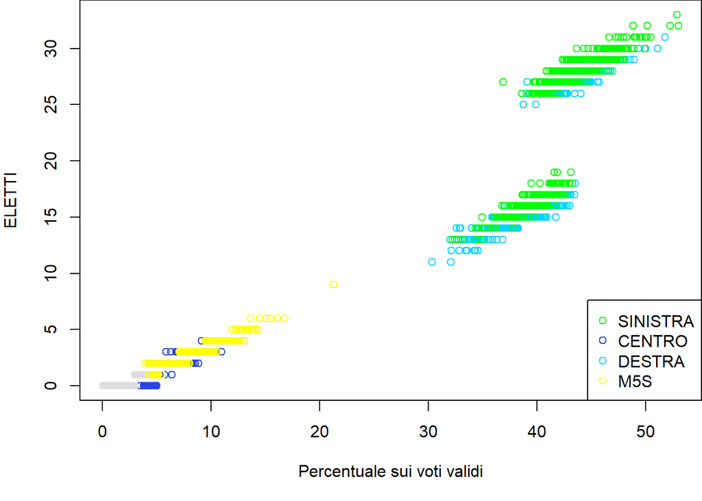

### Probabilità di elezione per ciascuna posizione nelle province

ALLEANZA VERDI E SINISTRA

|  | 1 | 2 | 3 | 4 | 5 | 6 | 7 | 8 | 9 |
| --- | --- | --- | --- | --- | --- | --- | --- | --- | --- |
| BOLOGNA | 99.4% | 3.4% | 0.0% | 0.0% | 0.0% | 0.0% | 0.0% | 0.0% | 0.0% |
| FERRARA | 0.6% | 0.0% | 0.0% | 0.0% | 0.0% | 0.0% | 0.0% | 0.0% | 0.0% |
| FORLI’-CESENA | 21.1% | 0.0% | 0.0% | 0.0% | 0.0% | 0.0% | 0.0% | 0.0% | 0.0% |
| MODENA | 70.5% | 0.0% | 0.0% | 0.0% | 0.0% | 0.0% | 0.0% | 0.0% | 0.0% |
| PARMA | 42.8% | 0.0% | 0.0% | 0.0% | 0.0% | 0.0% | 0.0% | 0.0% | 0.0% |
| PIACENZA | 3.4% | 0.0% | 0.0% | 0.0% | 0.0% | 0.0% | 0.0% | 0.0% | 0.0% |
| RAVENNA | 5.7% | 0.0% | 0.0% | 0.0% | 0.0% | 0.0% | 0.0% | 0.0% | 0.0% |
| REGGIO NELL’EMILIA | 62.6% | 0.0% | 0.0% | 0.0% | 0.0% | 0.0% | 0.0% | 0.0% | 0.0% |
| RIMINI | 7.5% | 0.0% | 0.0% | 0.0% | 0.0% | 0.0% | 0.0% | 0.0% | 0.0% |

AZIONE

|  | 1 | 2 | 3 | 4 | 5 | 6 | 7 | 8 | 9 |
| --- | --- | --- | --- | --- | --- | --- | --- | --- | --- |
| BOLOGNA | 90.9% | 0.0% | 0.0% | 0.0% | 0.0% | 0.0% | 0.0% | 0.0% | 0.0% |
| FERRARA | 0.0% | 0.0% | 0.0% | 0.0% | 0.0% | 0.0% | 0.0% | 0.0% | 0.0% |
| FORLI’-CESENA | 0.0% | 0.0% | 0.0% | 0.0% | 0.0% | 0.0% | 0.0% | 0.0% | 0.0% |
| MODENA | 3.3% | 0.0% | 0.0% | 0.0% | 0.0% | 0.0% | 0.0% | 0.0% | 0.0% |
| PARMA | 0.6% | 0.0% | 0.0% | 0.0% | 0.0% | 0.0% | 0.0% | 0.0% | 0.0% |
| PIACENZA | 0.0% | 0.0% | 0.0% | 0.0% | 0.0% | 0.0% | 0.0% | 0.0% | 0.0% |
| RAVENNA | 0.0% | 0.0% | 0.0% | 0.0% | 0.0% | 0.0% | 0.0% | 0.0% | 0.0% |
| REGGIO NELL’EMILIA | 0.0% | 0.0% | 0.0% | 0.0% | 0.0% | 0.0% | 0.0% | 0.0% | 0.0% |
| RIMINI | 0.0% | 0.0% | 0.0% | 0.0% | 0.0% | 0.0% | 0.0% | 0.0% | 0.0% |

FORZA ITALIA

|  | 1 | 2 | 3 | 4 | 5 | 6 | 7 | 8 | 9 |
| --- | --- | --- | --- | --- | --- | --- | --- | --- | --- |
| BOLOGNA | 66.9% | 0.3% | 0.0% | 0.0% | 0.0% | 0.0% | 0.0% | 0.0% | 0.0% |
| FERRARA | 7.9% | 0.0% | 0.0% | 0.0% | 0.0% | 0.0% | 0.0% | 0.0% | 0.0% |
| FORLI’-CESENA | 20.1% | 0.0% | 0.0% | 0.0% | 0.0% | 0.0% | 0.0% | 0.0% | 0.0% |
| MODENA | 50.5% | 0.0% | 0.0% | 0.0% | 0.0% | 0.0% | 0.0% | 0.0% | 0.0% |
| PARMA | 26.5% | 0.0% | 0.0% | 0.0% | 0.0% | 0.0% | 0.0% | 0.0% | 0.0% |
| PIACENZA | 25.5% | 0.0% | 0.0% | 0.0% | 0.0% | 0.0% | 0.0% | 0.0% | 0.0% |
| RAVENNA | 1.6% | 0.0% | 0.0% | 0.0% | 0.0% | 0.0% | 0.0% | 0.0% | 0.0% |
| REGGIO NELL’EMILIA | 27.9% | 0.0% | 0.0% | 0.0% | 0.0% | 0.0% | 0.0% | 0.0% | 0.0% |
| RIMINI | 4.9% | 0.0% | 0.0% | 0.0% | 0.0% | 0.0% | 0.0% | 0.0% | 0.0% |

FRATELLI D’ITALIA

|  | 1 | 2 | 3 | 4 | 5 | 6 | 7 | 8 | 9 |
| --- | --- | --- | --- | --- | --- | --- | --- | --- | --- |
| BOLOGNA | 100.0% | 99.1% | 48.5% | 7.8% | 0.1% | 0.0% | 0.0% | 0.0% | 0.0% |
| FERRARA | 100.0% | 35.0% | 0.4% | 0.0% | 0.0% | 0.0% | 0.0% | 0.0% | 0.0% |
| FORLI’-CESENA | 100.0% | 49.4% | 2.5% | 0.0% | 0.0% | 0.0% | 0.0% | 0.0% | 0.0% |
| MODENA | 100.0% | 88.3% | 16.1% | 0.0% | 0.0% | 0.0% | 0.0% | 0.0% | 0.0% |
| PARMA | 99.9% | 46.7% | 2.4% | 0.0% | 0.0% | 0.0% | 0.0% | 0.0% | 0.0% |
| PIACENZA | 100.0% | 41.8% | 1.0% | 0.0% | 0.0% | 0.0% | 0.0% | 0.0% | 0.0% |
| RAVENNA | 99.2% | 27.4% | 0.0% | 0.0% | 0.0% | 0.0% | 0.0% | 0.0% | 0.0% |
| REGGIO NELL’EMILIA | 100.0% | 41.8% | 1.8% | 0.0% | 0.0% | 0.0% | 0.0% | 0.0% | 0.0% |
| RIMINI | 99.8% | 32.4% | 0.1% | 0.0% | 0.0% | 0.0% | 0.0% | 0.0% | 0.0% |

LEGA

|  | 1 | 2 | 3 | 4 | 5 | 6 | 7 | 8 | 9 |
| --- | --- | --- | --- | --- | --- | --- | --- | --- | --- |
| BOLOGNA | 62.1% | 0.0% | 0.0% | 0.0% | 0.0% | 0.0% | 0.0% | 0.0% | 0.0% |
| FERRARA | 9.9% | 0.0% | 0.0% | 0.0% | 0.0% | 0.0% | 0.0% | 0.0% | 0.0% |
| FORLI’-CESENA | 1.3% | 0.0% | 0.0% | 0.0% | 0.0% | 0.0% | 0.0% | 0.0% | 0.0% |
| MODENA | 56.6% | 0.0% | 0.0% | 0.0% | 0.0% | 0.0% | 0.0% | 0.0% | 0.0% |
| PARMA | 56.3% | 0.0% | 0.0% | 0.0% | 0.0% | 0.0% | 0.0% | 0.0% | 0.0% |
| PIACENZA | 36.6% | 0.0% | 0.0% | 0.0% | 0.0% | 0.0% | 0.0% | 0.0% | 0.0% |
| RAVENNA | 0.2% | 0.0% | 0.0% | 0.0% | 0.0% | 0.0% | 0.0% | 0.0% | 0.0% |
| REGGIO NELL’EMILIA | 15.6% | 0.0% | 0.0% | 0.0% | 0.0% | 0.0% | 0.0% | 0.0% | 0.0% |
| RIMINI | 0.1% | 0.0% | 0.0% | 0.0% | 0.0% | 0.0% | 0.0% | 0.0% | 0.0% |

MOVIMENTO 5 STELLE

|  | 1 | 2 | 3 | 4 | 5 | 6 | 7 | 8 | 9 |
| --- | --- | --- | --- | --- | --- | --- | --- | --- | --- |
| BOLOGNA | 94.0% | 2.8% | 0.0% | 0.0% | 0.0% | 0.0% | 0.0% | 0.0% | 0.0% |
| FERRARA | 2.2% | 0.0% | 0.0% | 0.0% | 0.0% | 0.0% | 0.0% | 0.0% | 0.0% |
| FORLI’-CESENA | 12.8% | 0.0% | 0.0% | 0.0% | 0.0% | 0.0% | 0.0% | 0.0% | 0.0% |
| MODENA | 54.8% | 0.0% | 0.0% | 0.0% | 0.0% | 0.0% | 0.0% | 0.0% | 0.0% |
| PARMA | 16.2% | 0.0% | 0.0% | 0.0% | 0.0% | 0.0% | 0.0% | 0.0% | 0.0% |
| PIACENZA | 2.4% | 0.0% | 0.0% | 0.0% | 0.0% | 0.0% | 0.0% | 0.0% | 0.0% |
| RAVENNA | 5.4% | 0.0% | 0.0% | 0.0% | 0.0% | 0.0% | 0.0% | 0.0% | 0.0% |
| REGGIO NELL’EMILIA | 60.4% | 0.0% | 0.0% | 0.0% | 0.0% | 0.0% | 0.0% | 0.0% | 0.0% |
| RIMINI | 7.5% | 0.0% | 0.0% | 0.0% | 0.0% | 0.0% | 0.0% | 0.0% | 0.0% |

PARTITO DEMOCRATICO

|  | 1 | 2 | 3 | 4 | 5 | 6 | 7 | 8 | 9 |
| --- | --- | --- | --- | --- | --- | --- | --- | --- | --- |
| BOLOGNA | 100.0% | 100.0% | 99.9% | 91.3% | 57.8% | 4.1% | 0.0% | 0.0% | 0.0% |
| FERRARA | 99.9% | 67.1% | 0.0% | 0.0% | 0.0% | 0.0% | 0.0% | 0.0% | 0.0% |
| FORLI’-CESENA | 100.0% | 84.3% | 41.2% | 0.0% | 0.0% | 0.0% | 0.0% | 0.0% | 0.0% |
| MODENA | 100.0% | 100.0% | 80.6% | 41.6% | 0.0% | 0.0% | 0.0% | 0.0% | 0.0% |
| PARMA | 100.0% | 68.3% | 5.0% | 0.0% | 0.0% | 0.0% | 0.0% | 0.0% | 0.0% |
| PIACENZA | 96.7% | 57.8% | 0.0% | 0.0% | 0.0% | 0.0% | 0.0% | 0.0% | 0.0% |
| RAVENNA | 100.0% | 68.5% | 7.7% | 0.0% | 0.0% | 0.0% | 0.0% | 0.0% | 0.0% |
| REGGIO NELL’EMILIA | 100.0% | 99.9% | 68.3% | 6.3% | 0.0% | 0.0% | 0.0% | 0.0% | 0.0% |
| RIMINI | 100.0% | 67.3% | 0.0% | 0.0% | 0.0% | 0.0% | 0.0% | 0.0% | 0.0% |

STATI UNITI D’EUROPA

|  | 1 | 2 | 3 | 4 | 5 | 6 | 7 | 8 | 9 |
| --- | --- | --- | --- | --- | --- | --- | --- | --- | --- |
| BOLOGNA | 81.9% | 0.0% | 0.0% | 0.0% | 0.0% | 0.0% | 0.0% | 0.0% | 0.0% |
| FERRARA | 0.0% | 0.0% | 0.0% | 0.0% | 0.0% | 0.0% | 0.0% | 0.0% | 0.0% |
| FORLI’-CESENA | 1.1% | 0.0% | 0.0% | 0.0% | 0.0% | 0.0% | 0.0% | 0.0% | 0.0% |
| MODENA | 5.4% | 0.0% | 0.0% | 0.0% | 0.0% | 0.0% | 0.0% | 0.0% | 0.0% |
| PARMA | 3.4% | 0.0% | 0.0% | 0.0% | 0.0% | 0.0% | 0.0% | 0.0% | 0.0% |
| PIACENZA | 0.1% | 0.0% | 0.0% | 0.0% | 0.0% | 0.0% | 0.0% | 0.0% | 0.0% |
| RAVENNA | 0.4% | 0.0% | 0.0% | 0.0% | 0.0% | 0.0% | 0.0% | 0.0% | 0.0% |
| REGGIO NELL’EMILIA | 4.2% | 0.0% | 0.0% | 0.0% | 0.0% | 0.0% | 0.0% | 0.0% | 0.0% |
| RIMINI | 0.0% | 0.0% | 0.0% | 0.0% | 0.0% | 0.0% | 0.0% | 0.0% | 0.0% |

### Probabilità di elezione in base alla posizione nel listino

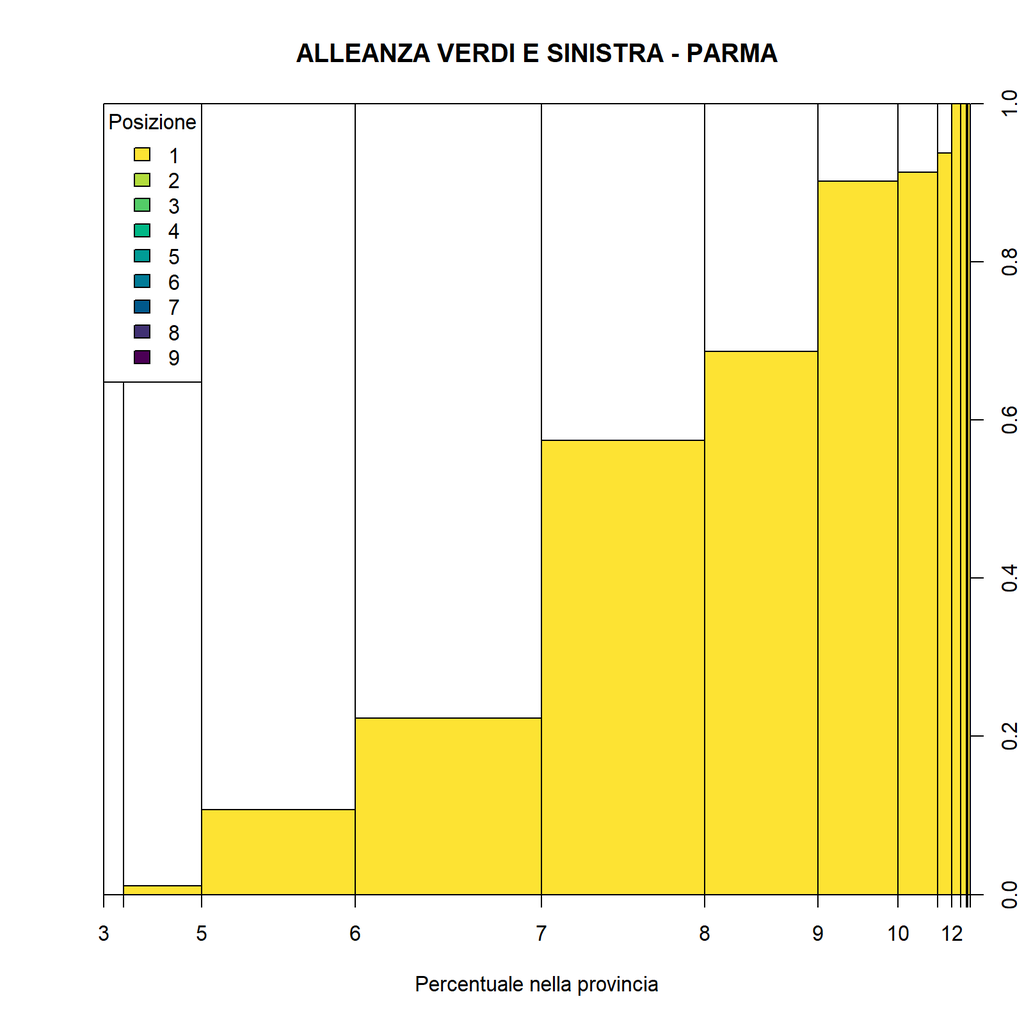

# Approfondimenti

Per predire il numero di voti che ciascuna lista prenderà alle prossime elezioni regionali in ciascuna provincia ho ipotizzato che i voti presi da ciascuna lista seguano il modello che descrivo qui di seguito.

Ho ipotizzato che la percentuale regionale (sul totale degli elettori) della lista $l$ nell’elezione $t$ (trasformata attraverso la funzione $\operatorname{logit}$ affinché non sia vincolata tra 0 e 1) sia uguale alla percentuale regionale della stessa lista nell’elezione precedente ($t-1$) (anch’essa trasformata tramite $\operatorname{logit}$), più una quantità (positiva o negativa) che dipende dal tempo trascorso tra le due elezioni e da una “velocità” di cambiamento casuale, con una distribuzione normale e una deviazione standard che può variare da lista a lista (ci saranno liste più stabili, le cui velocità di cambiamento saranno vicine allo zero, e liste meno stabili con velocità di cambiamento che possono discostarsi maggiormente dallo zero).

$$\operatorname{logit}(P_{l,t}) = \operatorname{logit}(P_{l,t-1})
+ (data_t - data_{t-1}) \cdot v_{R, l, t}$$

$$v_{R, l, t} \sim \mathcal{N}(0, \sigma_{R,l})$$

Dove

- $P_{l,t}$ è la percentuale regionale (sul totale degli aventi diritto al voto) della lista $l$ all’elezione $t$,
- $P_{t-1}$ è la percentuale della lista $l$ all’elezione precedente ($t-1$),
- $data_t$ e $data_{t-1}$ sono le date delle due elezioni,
- $v_{R, l, t}$ è la velocità di cambiamento della percentuale trasformata regionale della lista $l$ tra l’elezione $t-1$ e l’elezione $t$
- $\sigma_{R,l}$ è la deviazione standard delle velocità di cambiamento della percentuale (logit-trasformata) della lista $l$.

Ipotizzo poi che, per ciascuna provincia $p$, la percentuale provinciale $p_{l,p,t}$ della lista $l$ sul totale degli aventi diritto al voto (sempre trasformata tramite $\operatorname{logit}$) sia uguale alla percentuale regionale $P_{l,t}$ (trasformata) della stessa lista, più (o meno) una differenza $\delta_{l,p,t}$ specifica per la provincia:

$$\operatorname{logit}(p_{l,p,t}) = \operatorname{logit}(P_{l,t}) +
\delta_{l,p,t}$$

Ipotizzo infine che questa differenza possa cambiare tra un’elezione e l’altra di una quantità che dipende dal tempo trascorso e da una “velocità” casuale con una distribuzione normale e una deviazione standard $\sigma_{P, l}$ specifica per la lista:

$$\delta_{l, p, t} = \delta_{l, p, t-1} + (data_t - data_{t-1}) \cdot
v_{p, l, t}$$

$$v_{p, l, t} \sim \mathcal{N}(0, \sigma_{P,l})$$

Dove

- $v_{p, l, t}$ è la velocità di cambiamento di $\delta_{l,p,t}$ tra l’elezione $t-1$ e l’elezione $t$ nella provincia $p$,
- $\sigma_{P,l}$ è la deviazione standard della distribuzione delle velocità di cambiamento $v_{p, l, t}$.

In tutti questi casi considero l’astensione come una lista a sé.

Dai dati sulle elezioni precedenti ottengo quindi:

- per ciascuna lista $l$, la deviazione standard $\sigma_{R,l}$ delle velocità di cambiamento delle percentuali regionali trasformate;
- per ciascuna lista $l$, la deviaizone standard $\sigma_{P,l}$ delle velocità di cambiamento delle differenze tra ciascuna provincia e la regione;
- per ciascuna lista $l$, la percentuale regionale trasformata $\operatorname{logit}(P_{l,europee\ 2024})$ ottenuta alle ultime elezioni;
- per ciascuna lista $l$ e ciascuna provincia $p$, la differenza $\delta_{l,p,europee\ 2024}$ tra la percentuale trasformata provinciale e regionale alle ultime elezioni.

Per fare una simulazione dei voti delle prossime elezioni, quindi:

1. calcolo il tempo che trascorrerà tra le elezioni europee e una probabile data delle prossime elezioni regionali
2. estraggo a sorte, per ciascuna lista $l$, le velocità di cambiamento $v_{R, l, regionali\ 2024}$ delle percentuali regionali;
3. attraverso le equazioni sopra, calcolo le nuove percentuali regionali;
4. estraggo a sorte, per ciascuna lista $l$ e provincia $p$, le velocità di cambiamento $v_{p, l, regionali\ 2024}$ delle differenze provinciali;
5. attraverso le equazioni sopra, calcolo le nuove differenze provinciali e a seguire le nuove percentuali provinciali.

Le percentuali provinciali così ottenute vengono poi scalate in modo che la somma di tutte le percentuali della provincia faccia 1:

$$\hat{p}_{l, p, regionali\ 2024} = \frac{p_{l, p, regionali\ 2024}}
{\displaystyle{\sum_{l \in Liste } p_{l, p, regionali\ 2024}}}$$

dove $\hat{p}_{l,p, regionali\ 2024}$ è la percentuale scalata della lista $l$ nella provincia $p$, simulata per le prossime elezioni regionali.

Quest’ultima percentuale viene poi moltiplicata per gli elettori, per ottenere il numero di voti ricevuti da ciascuna lista in ciascuna provincia.

Con questi voti viene poi simulato uno scrutinio, seguendo quanto stabilito dalla legge elettorale regionale.

## Serie storica dei risultati delle liste

Di seguito la serie storica di elezioni considerate. Sono mostrate le percentuali di ciascuna lista rispetto al totale degli aventi diritto al voto.

In alcuni casi i risultati passati della lista sono basati sul risultato di liste affini.

I triangoli sulla destra comprendono il 95% dei risultati simulati di ciascuna lista alle prossime elezioni.

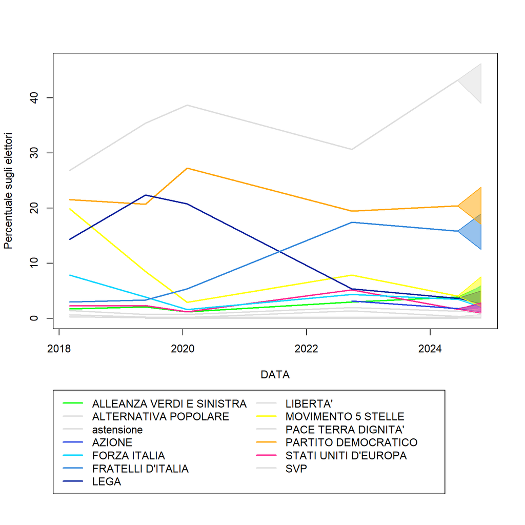